# Ejercicio 1: Aprobación de crédito

## 3. PARTICIÓN ENTRENAMIENTO / PRUEBA (ESTRATIFICADA)

Separamos los datos en entrenamiento (75%) y prueba (25%). Estratificamos por aprobado para que ambas particiones conserven la misma proporción de clases que el total. La base de prueba se “guarda en una caja fuerte”: solo la tocamos al final, para una evaluación honesta del modelo ya elegido.

```r
set.seed(2026)
creditos_split <- initial_split(data = creditos,
                                prop = 0.75,
                                strata = aprobado)
```

```r
creditos_entrenamiento <- creditos_split %>% training()
creditos_prueba        <- creditos_split %>% testing()
```

```r
# Verificamos que la estratificación preservó las proporciones.
table(creditos_entrenamiento$aprobado) %>% prop.table()
```

```
       no        si
0.4438202 0.5561798
```

```r
table(creditos_prueba$aprobado) %>% prop.table()
```

```
       no        si
0.4453782 0.5546218
```

## 4. RECETA DE FEATURE ENGINEERING

El ORDEN de los pasos importa. Imputamos PRIMERO porque los pasos posteriores (step_corr, step_normalize) no toleran NAs. Luego limpiamos variables sin información, filtramos colinealidad y normalizamos (clave para KNN). Todos los predictores son numéricos, así que no hace falta codificar categóricas.

1. step_impute_median: rellena los NAs numéricos con la mediana (robusta a valores extremos como ingresos muy altos).
2. step_nzv: elimina predictores con varianza casi nula (casi constantes), que no ayudan a discriminar.
3. step_corr: descarta predictores numéricos redundantes por colinealidad (umbral 0.7), para que la información no pese doble en la distancia.
4. step_normalize: estandariza (media 0, desviación 1) los predictores numéricos. ES EL PASO CRÍTICO PARA KNN: sin él, una variable como monto_solicitado_mxn (en miles de pesos) aplastaría a otras como num_creditos_activos en el cálculo de distancias.
5. step_zv: por seguridad, elimina cualquier variable que quedara con varianza cero tras los pasos anteriores.

```r
receta_creditos <- recipe(aprobado ~ ., data = creditos_entrenamiento) %>%
  step_impute_median(all_numeric_predictors()) %>%
  step_nzv(all_predictors()) %>%
  step_corr(all_numeric_predictors(), threshold = 0.7) %>%
  step_normalize(all_numeric_predictors()) %>%
  step_zv(all_predictors())
```

```r
# Inspección opcional: preparamos la receta y "horneamos" el entrenamiento
# solo para ver cómo quedaron las variables tras el preprocesamiento.
receta_creditos %>%
  prep(training = creditos_entrenamiento) %>%
  bake(new_data = NULL) %>%
  glimpse()
```

```
Rows: 712
Columns: 8
$ edad                    <dbl> -0.96044958, -1.31982950, 0.29738016, -1.25993…
$ ingreso_mensual_mxn     <dbl> -1.26148623, 0.78763404, -0.86083114, -1.25226…
$ plazo_meses             <dbl> -0.9701442, -1.3465708, -1.3465708, -0.2172912…
$ pct_deuda_ingreso       <dbl> 1.50978362, 1.61010420, 2.75993244, -0.2574020…
$ score_historial         <dbl> -0.08607179, 0.25199369, 0.78823549, 1.7558022…
$ num_creditos_activos    <dbl> -1.2386027, -0.4931377, -0.4931377, 0.9977924,…
$ antiguedad_empleo_anios <dbl> 1.06079890, -1.10497773, 0.36465641, -1.001845…
$ aprobado                <fct> no, no, no, no, no, no, no, no, no, no, no, no…
```

## 5. WORKFLOW + MODELO KNN CON k FIJO (ARBITRARIO)

¿Qué es un workflow? Un workflow empaqueta en un solo objeto la receta de preprocesamiento y la especificación del modelo. Su ventaja: fit() hace internamente prep+bake +fit, y predict() aplica el mismo preprocesamiento a los datos nuevos sin que tengamos que recordar el bake() manual. Es la pieza estándar para tuning y validación cruzada.

¿Qué es KNN? Es un modelo basado en distancias: para clasificar una observación nueva, busca las k observaciones más parecidas de la base de entrenamiento y vota la clase mayoritaria entre esas k vecinas. No “aprende” parámetros como una regresión; memoriza el entrenamiento (es un modelo “perezoso”). El número de vecinos k gobierna el equilibrio sesgo-varianza:

- k pequeño => frontera muy flexible, baja sesgo pero alta varianza (puede sobreajustar al ruido).
- k grande => frontera muy suave, alto sesgo pero baja varianza (puede subajustar).

Aquí fijamos k = 7 “a ojo”, solo para tener un punto de partida. En la sección siguiente lo elegiremos con datos.

```r
# weight_func = "rectangular": usamos KNN de VOTO MAYORITARIO no ponderado
# (los k vecinos pesan igual). Es la versión clásica de KNN y deja ver con
# claridad el equilibrio sesgo-varianza: con k muy grande la frontera se
# aplana y el modelo subajusta. El motor kknn por defecto pondera por
# distancia (los vecinos lejanos pesan poco), lo que disimularía ese
# subajuste y haría que "más k" casi nunca empeore.
modelo_knn_fijo <- nearest_neighbor(neighbors = 7,
                                    weight_func = "rectangular") %>%
  set_engine("kknn") %>%
  set_mode("classification")
```

```r
workflow_knn_fijo <- workflow() %>%
  add_recipe(receta_creditos) %>%
  add_model(modelo_knn_fijo)
```

```r
# Ajustamos el workflow sobre el entrenamiento (SIN bake manual).
workflow_knn_fijo_fit <- workflow_knn_fijo %>%
  fit(data = creditos_entrenamiento)
```

```r
# Predecimos sobre la prueba (el workflow aplica el preprocesamiento solo).
predicciones_knn_fijo <- creditos_prueba %>%
  select(aprobado) %>%
  bind_cols(predict(workflow_knn_fijo_fit, creditos_prueba, type = "class")) %>%
  bind_cols(predict(workflow_knn_fijo_fit, creditos_prueba, type = "prob"))
```

```r
# Métricas de referencia con k = 7.
metricas_clasificacion <- metric_set(accuracy, sensitivity, yardstick::spec)
metricas_clasificacion(predicciones_knn_fijo,
                       truth = aprobado,
                       estimate = .pred_class)
```

```
# A tibble: 3 × 3
  .metric     .estimator .estimate
  <chr>       <chr>          <dbl>
1 accuracy    binary         0.714
2 sensitivity binary         0.519
3 spec        binary         0.871
```

```r
roc_auc(predicciones_knn_fijo, truth = aprobado, .pred_no)
```

```
# A tibble: 1 × 3
  .metric .estimator .estimate
  <chr>   <chr>          <dbl>
1 roc_auc binary         0.752
```

## 6. TUNING DE k CON VALIDACIÓN CRUZADA

k es un HIPERPARÁMETRO: no se aprende de los datos durante el entrenamiento, lo fija el analista antes. Elegirlo “a ojo” (como el k = 7 de arriba) es arbitrario. Lo correcto es probar varios valores y quedarnos con el que mejor desempeño estimado da.

NO podemos usar la base de prueba para elegir k: si la usáramos, dejaría de ser una evaluación honesta. La solución es validación cruzada SOLO sobre el entrenamiento.

¿Qué es un fold y qué pasa en cada iteración de la CV? Partimos el entrenamiento en v “folds” (porciones) del mismo tamaño. En cada iteración: usamos v-1 folds para entrenar y el fold restante para validar; rotamos cuál fold se deja fuera, de modo que cada porción sirve de validación exactamente una vez. Promediamos la métrica de validación a lo largo de los v folds. Repetimos todo para cada k candidato y elegimos el k con mejor promedio. Esto aprovecha todo el entrenamiento sin tocar la prueba.

```r
# 6.1 Modelo KNN dejando neighbors como tune() (a determinar). Mantenemos
# weight_func = "rectangular" para que el tuning revele el k intermedio
# óptimo (con voto ponderado el AUC casi no bajaría al crecer k).
modelo_knn_tune <- nearest_neighbor(neighbors = tune(),
                                    weight_func = "rectangular") %>%
  set_engine("kknn") %>%
  set_mode("classification")
```

```r
workflow_knn_tune <- workflow() %>%
  add_recipe(receta_creditos) %>%
  add_model(modelo_knn_tune)
```

```r
# 6.2 Folds de validación cruzada estratificada (v = 5) sobre el
# entrenamiento. set.seed() para que la partición en folds sea reproducible.
set.seed(2026)
folds_cv <- vfold_cv(data = creditos_entrenamiento,
                     v = 5,
                     strata = aprobado)
```

```r
# 6.3 Grilla de valores candidatos de k. Usamos grid_regular() sobre el
# parámetro neighbors(): genera una cuadrícula uniforme dentro de un rango.
# Probamos varios k para ver toda la curva sesgo-varianza.
# Regla práctica: si el mejor k cae justo en el borde de la grilla, conviene
# ampliarla, porque podría existir un k mejor más allá del rango probado.
grilla_k <- grid_regular(neighbors(range = c(1, 101)),
                         levels = 12)
```

```r
# 6.4 Métricas a vigilar durante el tuning. roc_auc es la métrica principal
# (no depende de un umbral fijo); accuracy, sensibilidad y especificidad la
# complementan.
metricas_tuning <- metric_set(roc_auc, accuracy, sensitivity, yardstick::spec)
```

```r
# 6.5 Ejecutar el tuning: para cada k de la grilla, corre la CV de 5 folds.
set.seed(2026)
resultados_tuning <- workflow_knn_tune %>%
  tune_grid(resamples = folds_cv,
            grid = grilla_k,
            metrics = metricas_tuning)
```

```r
# 6.6 Inspeccionar los resultados promediados por k.
collect_metrics(resultados_tuning)
```

```
# A tibble: 48 × 7
   neighbors .metric     .estimator  mean     n std_err .config
       <int> <chr>       <chr>      <dbl> <int>   <dbl> <chr>
 1         1 accuracy    binary     0.674     5 0.0160  pre0_mod01_post0
 2         1 roc_auc     binary     0.666     5 0.0164  pre0_mod01_post0
 3         1 sensitivity binary     0.592     5 0.0213  pre0_mod01_post0
 4         1 spec        binary     0.740     5 0.0153  pre0_mod01_post0
 5        10 accuracy    binary     0.723     5 0.0157  pre0_mod02_post0
 6        10 roc_auc     binary     0.802     5 0.0116  pre0_mod02_post0
 7        10 sensitivity binary     0.525     5 0.0170  pre0_mod02_post0
 8        10 spec        binary     0.881     5 0.0199  pre0_mod02_post0
 9        19 accuracy    binary     0.715     5 0.00787 pre0_mod03_post0
10        19 roc_auc     binary     0.805     5 0.0115  pre0_mod03_post0
# ℹ 38 more rows
```

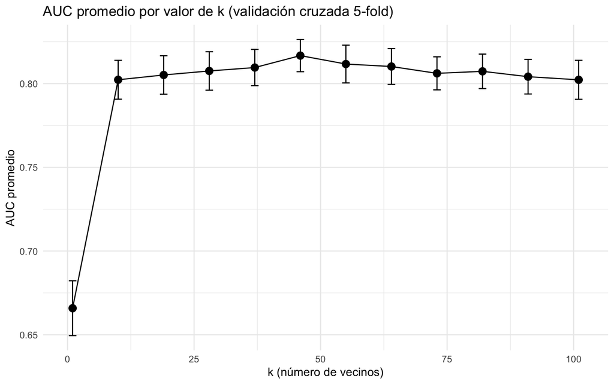

```r
# Gráfica de AUC promedio vs k (con barras de error ±1 error estándar).
# Buscamos el k donde el AUC se estabiliza en su valor más alto.
resultados_tuning %>%
  collect_metrics() %>%
  filter(.metric == "roc_auc") %>%
  ggplot(aes(x = neighbors, y = mean)) +
  geom_line() +
  geom_point(size = 3) +
  geom_errorbar(aes(ymin = mean - std_err, ymax = mean + std_err),
                width = 1.5) +
  labs(title = "AUC promedio por valor de k (validación cruzada 5-fold)",
       x = "k (número de vecinos)",
       y = "AUC promedio") +
  theme_minimal()
```

```r
# 6.7 Elegir el mejor k según AUC.
mejor_k <- resultados_tuning %>% select_best(metric = "roc_auc")
mejor_k
```

```
# A tibble: 1 × 2
  neighbors .config
      <int> <chr>
1        46 pre0_mod06_post0
```

## 7. EVALUACIÓN FINAL CON last_fit()

Finalizamos el workflow inyectando el k ganador con finalize_workflow(). Luego usamos last_fit(), que en un solo paso: reentrena el modelo final sobre TODO el entrenamiento y lo evalúa sobre la base de prueba que habíamos reservado. Así obtenemos la estimación honesta del desempeño en datos no vistos.

```r
workflow_knn_final <- workflow_knn_tune %>%
  finalize_workflow(mejor_k)
```

```r
ajuste_final <- workflow_knn_final %>%
  last_fit(split = creditos_split,
           metrics = metricas_tuning)
```

```r
# 7.1 Métricas finales sobre la prueba (incluye AUC y accuracy).
collect_metrics(ajuste_final)
```

```
# A tibble: 4 × 4
  .metric     .estimator .estimate .config
  <chr>       <chr>          <dbl> <chr>
1 accuracy    binary         0.647 pre0_mod0_post0
2 sensitivity binary         0.255 pre0_mod0_post0
3 spec        binary         0.962 pre0_mod0_post0
4 roc_auc     binary         0.725 pre0_mod0_post0
```

```r
# 7.2 Predicciones finales sobre la prueba.
predicciones_finales <- collect_predictions(ajuste_final)
predicciones_finales
```

```
# A tibble: 238 × 7
   .pred_class .pred_no .pred_si id               aprobado  .row .config
   <fct>          <dbl>    <dbl> <chr>            <fct>    <int> <chr>
 1 si             0.261    0.739 train/test split si           1 pre0_mod0_post0
 2 si             0.261    0.739 train/test split si           6 pre0_mod0_post0
 3 si             0.5      0.5   train/test split no           8 pre0_mod0_post0
 4 si             0.261    0.739 train/test split si          19 pre0_mod0_post0
 5 si             0.174    0.826 train/test split si          21 pre0_mod0_post0
 6 si             0.196    0.804 train/test split si          24 pre0_mod0_post0
 7 si             0.217    0.783 train/test split no          30 pre0_mod0_post0
 8 si             0.152    0.848 train/test split no          31 pre0_mod0_post0
 9 si             0.283    0.717 train/test split si          36 pre0_mod0_post0
10 si             0.457    0.543 train/test split si          40 pre0_mod0_post0
# ℹ 228 more rows
```

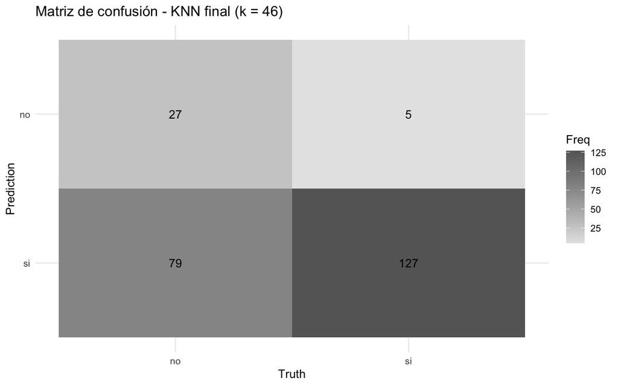

```r
# 7.3 Matriz de confusión final.
conf_mat(predicciones_finales,
         truth = aprobado,
         estimate = .pred_class) %>%
  autoplot(type = "heatmap") +
  labs(title = paste0("Matriz de confusión - KNN final (k = ",
                      mejor_k$neighbors, ")")) +
  theme_minimal()
```

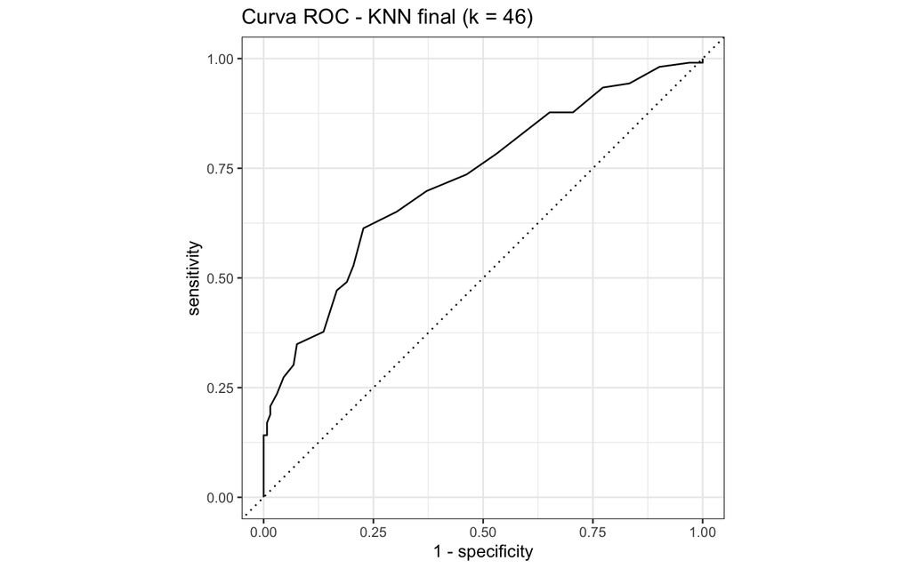

```r
# 7.4 Curva ROC y AUC final.
predicciones_finales %>%
  roc_curve(truth = aprobado, .pred_no) %>%
  autoplot() +
  labs(title = paste0("Curva ROC - KNN final (k = ", mejor_k$neighbors, ")"))
```

```r
roc_auc(predicciones_finales, truth = aprobado, .pred_no)
```

```
# A tibble: 1 × 3
  .metric .estimator .estimate
  <chr>   <chr>          <dbl>
1 roc_auc binary         0.725
```